# Семинар 8. Кросс-валидация

Июнь, 25, 2018

Шаманское заклинание для настройки глобальных опций отчёта:

```r
library(tidyverse) # обработка данных, графики...
library(skimr) # описательные статистики
library(rio) # импорт фантастического количества форматов данных
library(ISLR) # ещё данные
library(caret) # пакет для подбора параметров разных моделей
library(FFTrees) # быстрые деревья
library(margins) # для подсчёта предельных эффектов
library(rpart.plot) # для картинок деревьев
library(plotROC) # визуализация ROC-кривой
library(ggeffects) # графики для предельных эффектов
library(MLmetrics) # метрики качества
library(ranger) # случайный лес
library(factoextra) # графики для кластеризации и pca
library(elasticnet) # LASSO
library(latex2exp) # формулы в подписях к графику
library(distances) # расчет различных расстояний
```

Снова импортируем набор данных по успеваемости студентов и смотрим на него :)

```r
educ <- import('data/xAPI-Edu-Data.csv')
skim(educ)
```

```
## Skim summary statistics
##  n obs: 480
##  n variables: 17
##
## Variable type: character
##                  variable missing complete   n min max empty n_unique
##                     Class       0      480 480   1   1     0        3
##                    gender       0      480 480   1   1     0        2
##                   GradeID       0      480 480   4   4     0       10
##               NationalITy       0      480 480   2  11     0       14
##     ParentAnsweringSurvey       0      480 480   2   3     0        2
##  ParentschoolSatisfaction       0      480 480   3   4     0        2
##              PlaceofBirth       0      480 480   3  11     0       14
##                  Relation       0      480 480   3   6     0        2
##                 SectionID       0      480 480   1   1     0        3
##                  Semester       0      480 480   1   1     0        2
##                   StageID       0      480 480  10  12     0        3
##        StudentAbsenceDays       0      480 480   7   7     0        2
##                     Topic       0      480 480   2   9     0       12
##
## Variable type: integer
##           variable missing complete   n  mean    sd p0   p25 p50 p75 p100
##  AnnouncementsView       0      480 480 37.92 26.61  0 14     33  58   98
##         Discussion       0      480 480 43.28 27.64  1 20     39  70   99
##        raisedhands       0      480 480 46.77 30.78  0 15.75  50  75  100
##   VisITedResources       0      480 480 54.8  33.08  0 20     65  84   99
##      hist
##  ▇▆▅▅▅▃▃▂
##  ▇▇▇▇▃▅▅▃
##  ▇▆▃▃▃▆▆▃
##  ▆▃▂▁▃▃▇▇
```

Данные взяты с [kaggle.com](https://www.kaggle.com/aljarah/xAPI-Edu-Data/). Целевая переменная — успеваемость студента, `Class`, принимает три значения, ‘H’ (high), ‘M’ (mid), ‘L’ (low). Остальные переменные — характеристики студента.

Повторяем шаги предыдущего семинара:

1. Для целей бинарной классификации объединяем две верхних категории в одну
2. Уберём старую переменную ‘Class’ с тремя категориями
3. Объявляем все текстовые переменные факторными:

```r
educ_logit <- mutate(educ, y = fct_collapse(Class, H = c('M', 'H'))) %>%
  select(-Class)
educ_fct <- mutate_if(educ_logit, is.character, factor)
```

По умолчанию, базовой категорией факторной переменной будет категория, название которой стоит раньше в алфавите. В нашем примере ‘H’ идёт в алфавите раньше ‘L’, поэтому при построении логистической регрессии категория ‘H’ будет соответствовать $y_i=0$ в формулах, а категория ‘L’ — $y_i=1$. Следовательно, положительный коэффициент при регрессоре будет означать его положительное влияение на вероятность ‘L’.

Конечно, можно не полагаться на алфавит и самому указать любую базовую категорию.

Создадим другую набор данных с альтернативной базовой категорией:

```r
educ_fct_rel <- mutate(educ_fct, y = fct_relevel(y, 'L'))
```

3. Разбиваем выборку на две части: 80% в обучающей и 20% в тестовой

```r
set.seed(777)
train_rows <- createDataPartition(educ_fct$y, p = 0.8, list = FALSE)
educ_train <- educ_fct[train_rows, ]
educ_test <- educ_fct[-train_rows, ]
```

- Упражнение 1.

Разделите набор данных `Default` из пакета `ISLR` на обучающую и тестовую выборки так, чтобы в первую попало 70% всех наблюдений.

```r
def <- Default
glimpse(def)
```

```
## Observations: 10,000
## Variables: 4
## $ default <fct> No, No, No, No, No, No, No, No, No, No, No, No, No, No...
## $ student <fct> No, Yes, No, No, No, Yes, No, Yes, No, No, Yes, Yes, N...
## $ balance <dbl> 729.5265, 817.1804, 1073.5492, 529.2506, 785.6559, 919...
## $ income  <dbl> 44361.625, 12106.135, 31767.139, 35704.494, 38463.496,...
```

```r
set.seed(777)
train_rows <- createDataPartition(def$default, p = 0.7, list = FALSE)
def_train <- def[train_rows, ]
def_test <- def[-train_rows, ]
```

# 1 Логистическая регрессия

Оцениваем логистическую регрессию с помощью пакета `caret`.

```r
educ_lmodel <- train(data = educ_train,
  y ~ gender + SectionID + raisedhands, family = binomial(link = 'logit'),
  method = 'glm')
summary(educ_lmodel)
```

```
##
## Call:
## NULL
##
## Deviance Residuals:
##     Min       1Q   Median       3Q      Max
## -1.8009  -0.4881  -0.1803   0.6427   3.2122
##
## Coefficients:
##              Estimate Std. Error z value Pr(>|z|)
## (Intercept)  0.745737   0.365406   2.041  0.04127 *
## genderM      1.004068   0.335521   2.993  0.00277 **
## SectionIDB  -0.348347   0.319917  -1.089  0.27621
## SectionIDC  -0.702561   0.601374  -1.168  0.24270
## raisedhands -0.069383   0.008099  -8.567  < 2e-16 ***
## ---
## Signif. codes:  0 '***' 0.001 '**' 0.01 '*' 0.05 '.' 0.1 ' ' 1
##
## (Dispersion parameter for binomial family taken to be 1)
##
##     Null deviance: 445.18  on 384  degrees of freedom
## Residual deviance: 271.91  on 380  degrees of freedom
## AIC: 281.91
##
## Number of Fisher Scoring iterations: 6
```

- Упражнение 2.

Оцените заново логистическую регессию по набору данных `def` с помощью функций пакета `caret`.

```r
def_lmodel <- train(data = def_train, default ~ ., family = binomial(link = 'logit'), method = 'glm')
summary(def_lmodel)
```

```
##
## Call:
## NULL
##
## Deviance Residuals:
##     Min       1Q   Median       3Q      Max
## -2.5134  -0.1415  -0.0537  -0.0193   3.6837
##
## Coefficients:
##               Estimate Std. Error z value Pr(>|z|)
## (Intercept) -1.101e+01  5.951e-01 -18.498   <2e-16 ***
## studentYes  -6.193e-01  2.847e-01  -2.176   0.0296 *
## balance      5.786e-03  2.810e-04  20.587   <2e-16 ***
## income       5.782e-06  9.853e-06   0.587   0.5573
## ---
## Signif. codes:  0 '***' 0.001 '**' 0.01 '*' 0.05 '.' 0.1 ' ' 1
##
## (Dispersion parameter for binomial family taken to be 1)
##
##     Null deviance: 2050.6  on 7000  degrees of freedom
## Residual deviance: 1098.9  on 6997  degrees of freedom
## AIC: 1106.9
##
## Number of Fisher Scoring iterations: 8
```

Посторим прогнозы модели для тестовых данных `educ_test`. Для этого будем использовать функцию `predict`, которой передадим оценённую модель `educ_lmodel`. В переменной `educ_predz` уже будут лежать предсказанные классы. Чтобы получить их вероятности, нужно добавить аргумент `type = 'prob'`.

```r
educ_pred <- predict(educ_lmodel, newdata = educ_test)
head(educ_pred)
```

```
## [1] L H L H H L
## Levels: H L
```

```r
educ_prob <- predict(educ_lmodel, newdata = educ_test, type = 'prob')
head(educ_prob)
```

```
##            H         L
## 25 0.1975849 0.8024151
## 31 0.8432553 0.1567447
## 37 0.3001891 0.6998109
## 45 0.8240289 0.1759711
## 50 0.7801183 0.2198817
## 55 0.2855258 0.7144742
```

- Упражнение 3.

Постройте прогнозы для тестовой выборки `def_test`. Сохраните как предсказанные классы, так и их вероятности.

```r
def_pred <- predict(def_lmodel, newdata = def_test)
head(def_pred)
```

```
## [1] No No No No No No
## Levels: No Yes
```

```r
def_prob <- predict(def_lmodel, newdata = def_test, type = 'prob')
head(def_prob)
```

```
##           No          Yes
## 2  0.9989207 1.079261e-03
## 3  0.9901872 9.812833e-03
## 4  0.9995653 4.346734e-04
## 5  0.9980561 1.943937e-03
## 6  0.9981011 1.898868e-03
## 11 0.9999899 1.011236e-05
```

Теперь мы можем посмотреть на матрицу ошибок и узнать, насколько хорошую модель мы оценили. Для этого будем использовть функцию `confusionMatrix` из пакета `caret`. В качестве аргумента `data` нужно указать предсказанные значения, а в `reference` — правильные ответы.

```r
confusionMatrix(data = educ_pred, reference = educ_test$y)
```

```
## Confusion Matrix and Statistics
##
##           Reference
## Prediction  H  L
##          H 65  8
##          L  5 17
##
##                Accuracy : 0.8632
##                  95% CI : (0.7774, 0.9251)
##     No Information Rate : 0.7368
##     P-Value [Acc > NIR] : 0.002303
##
##                   Kappa : 0.633
##  Mcnemar's Test P-Value : 0.579100
##
##             Sensitivity : 0.9286
##             Specificity : 0.6800
##          Pos Pred Value : 0.8904
##          Neg Pred Value : 0.7727
##              Prevalence : 0.7368
##          Detection Rate : 0.6842
##    Detection Prevalence : 0.7684
##       Balanced Accuracy : 0.8043
##
##        'Positive' Class : H
##
```

- Упражнение 4.

Составьте матрицу ошибок для прогнозов модели `def_lmodel`.

```r
confusionMatrix(data = def_pred, reference = def_test$default)
```

```
## Confusion Matrix and Statistics
##
##           Reference
## Prediction   No  Yes
##        No  2885   65
##        Yes   15   34
##
##                Accuracy : 0.9733
##                  95% CI : (0.9669, 0.9788)
##     No Information Rate : 0.967
##     P-Value [Acc > NIR] : 0.02642
##
##                   Kappa : 0.4474
##  Mcnemar's Test P-Value : 4.293e-08
##
##             Sensitivity : 0.9948
##             Specificity : 0.3434
##          Pos Pred Value : 0.9780
##          Neg Pred Value : 0.6939
##              Prevalence : 0.9670
##          Detection Rate : 0.9620
##    Detection Prevalence : 0.9837
##       Balanced Accuracy : 0.6691
##
##        'Positive' Class : No
##
```

Чтобы получичть и другие метрики качества для нашей модели, будем использовать функции `twoClassSummary()` и `prSummary()`. Первая возвращает значения ROC, специфичности и чувствительности.

ROC — это площадь под кривой, построенной в осях доли правильных положительных ответов и доли неправильных положительных ответов в зависимости от значения порога для попадания в положительный класс.

Вторая функция возвращает AUC, полноту, точность и F-меру.

AUC — это площадь под кривой, построенной в осях точность-полнота. Точность — это доля объектов на самом деле принадлежащих к положительному классу среди всех объектов, которых модель отнесла к положительному классу.
$$precision = TP / (TP + FP)$$

А F-мера — это среднее гармоническое между точностью и полнотой.

Однако обе функции требуют, чтобы в данных были столбцы с вероятностями классов под названиями самих этих классов, истинные ответы под названием `obs`, и бинарные предсказания, названные `pred`. Поэтому создадим отдельную таблицу `educ_test_set` со всеми результатами оценивания.

```r
educ_test_set <- data.frame(H = educ_prob$H,
                            L = educ_prob$L,
                            pred = educ_pred,
                            obs = educ_test$y)
glimpse(educ_test_set)
```

```
## Observations: 95
## Variables: 4
## $ H    <dbl> 0.1975849, 0.8432553, 0.3001891, 0.8240289, 0.7801183, 0....
## $ L    <dbl> 0.802415134, 0.156744738, 0.699810922, 0.175971069, 0.219...
## $ pred <fct> L, H, L, H, H, L, H, L, L, H, L, L, H, H, L, H, H, H, H, ...
## $ obs  <fct> L, H, L, H, H, L, H, L, L, H, H, L, H, H, L, H, L, H, L, ...
```

```r
levs <- levels(educ_test_set$obs)

twoClassSummary(educ_test_set, lev = levs) # don't work with tibble
```

```
##       ROC      Sens      Spec
## 0.9037143 0.9285714 0.6800000
```

```r
prSummary(educ_test_set, lev = levs) # нужен пакет MLmetrics
```

```
##       AUC Precision    Recall         F
## 0.9300243 0.8904110 0.9285714 0.9090909
```

- Что находится в векторе `levs`?
- Упражнение 5.

Выведите характеристики модели `def_lmodel` с помощью функций `twoClassSummary()` и `prSummary()`.

```r
def_test_set <- data.frame(No = def_prob$No,
                           Yes = def_prob$Yes,
                           pred = def_pred,
                           obs = def_test$default)

twoClassSummary(def_test_set, lev = levels(def_test_set$obs))
```

```
##       ROC      Sens      Spec
## 0.9495472 0.9948276 0.3434343
```

```r
prSummary(def_test_set, lev = levels(def_test_set$obs))
```

```
##       AUC Precision    Recall         F
## 0.9977132 0.9779661 0.9948276 0.9863248
```

Почти все метрики можно визуализировать! Но для примера мы построим ROC-кривую. Для этого вдобавок к базовому слою `ggplot` мы будем использовать слой `geom_roc` из пакета `plotROC`. В эстетиках нужно указать аргументы `d` — истинные значения — и `m` — метки положительного класса. Если добавить аргумент `color`, то можно получить разные ROC-кривые по категориям какой-нибудь переменной.

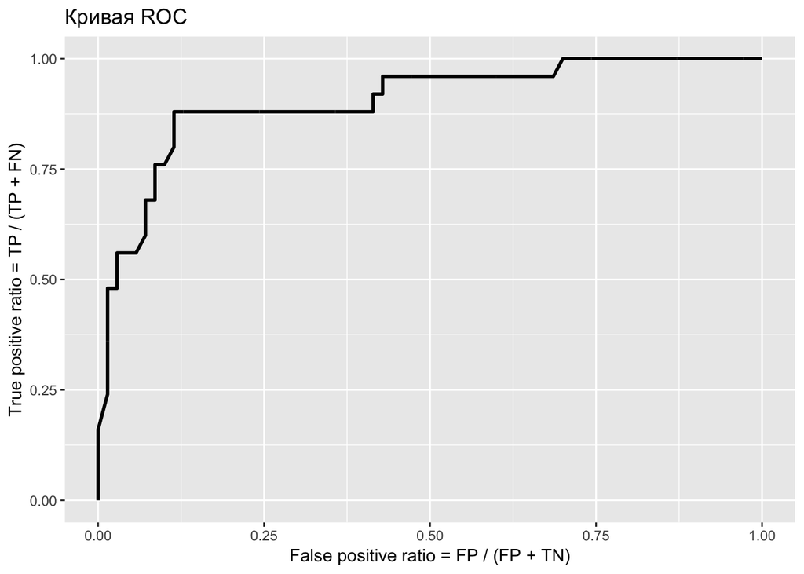

```r
ggplot(educ_test_set, aes(d = obs, m = L)) +
  geom_roc(n.cuts = 0) +
  labs(title = 'Кривая ROC',
       x = 'False positive ratio = FP / (FP + TN)',
       y = 'True positive ratio = TP / (TP + FN)')
```

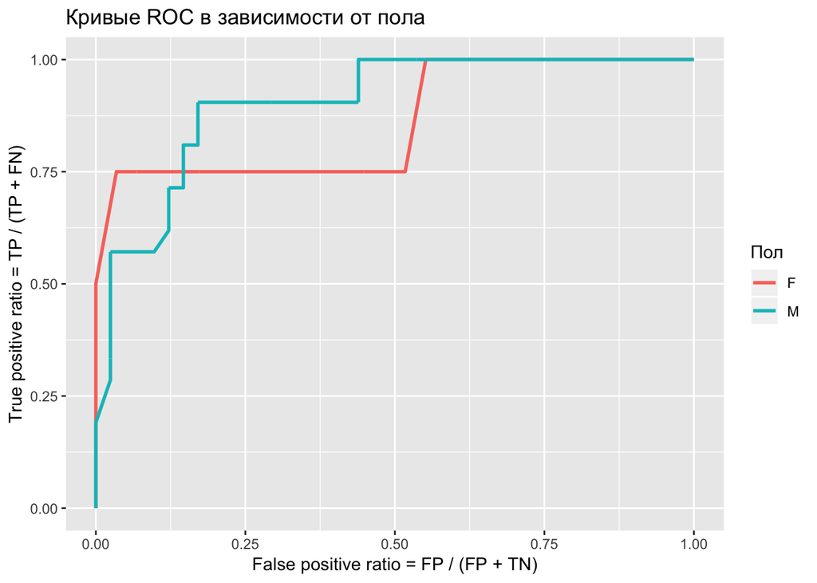

```r
educ_test_set <- mutate(educ_test_set, gender = educ_test$gender)

ggplot(educ_test_set, aes(d = obs, m = L, color = gender)) +
  geom_roc(n.cuts = 0) +
  labs(title = 'Кривые ROC в зависимости от пола',
       x = 'False positive ratio = FP / (FP + TN)',
       y = 'True positive ratio = TP / (TP + FN)',
       color = 'Пол')
```

- Упражнение 6.

Визуализируйте ROC-кривую для прогнозов модели `def_lmodel`. Сначала общую, а затем отдельно для студентов и всех остальных.

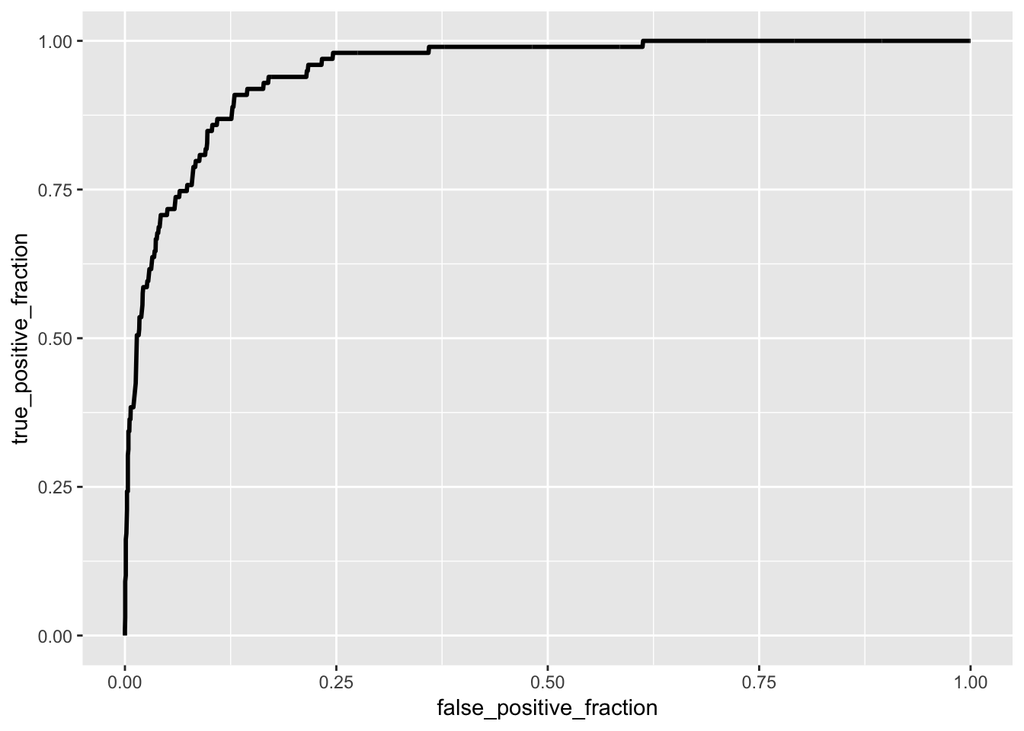

```r
ggplot(def_test_set, aes(d = obs, m = Yes)) +
  geom_roc(n.cuts = 0)
```

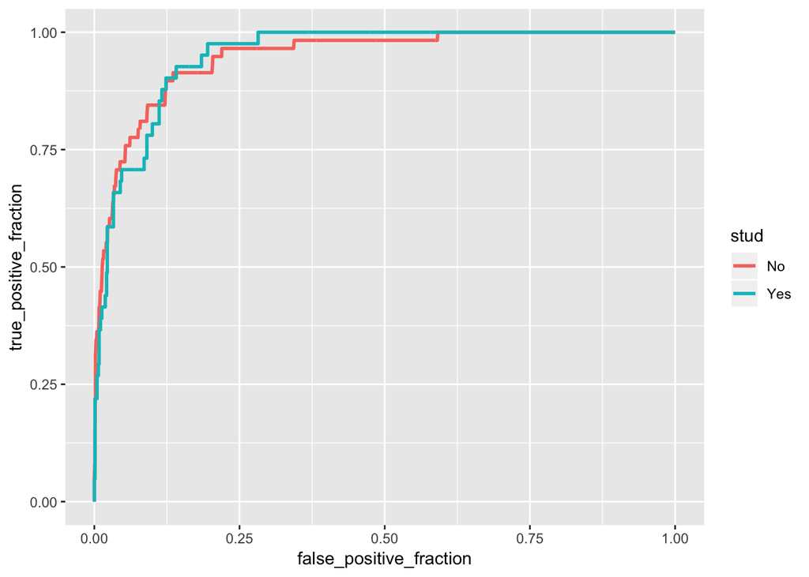

```r
def_test_set <- mutate(def_test_set, stud = def_test$student)

ggplot(def_test_set, aes(d = obs, m = Yes, color = stud)) +
  geom_roc(n.cuts = 0)
```

# 2 На природу, к деревьям и в лес!

? Пакет `caret` представляет собой общий интерфейс ко многим моделям, однако некоторые модели он ещё не поддерживает. Например, быстрые и стройные, [fast and frugal](https://cran.r-project.org/web/packages/FFTrees/vignettes/FFTrees_heart.html), деревья.

Быстрые деревья нужны, например, в медицине, чтобы создавать быстрые и простые рекомендации для спасения жизни.

Мы применим их для спасения неуспевающих студентов :) Увы, пакет принимает на вход только 0/1 в зависимой переменной, поэтому заменим названия категорий на числа:

```r
educ_train2 <- mutate(educ_train, ybin = ifelse(y == 'H', 1, 0))
```

И построим картинку для быстрого и стройного дерева:

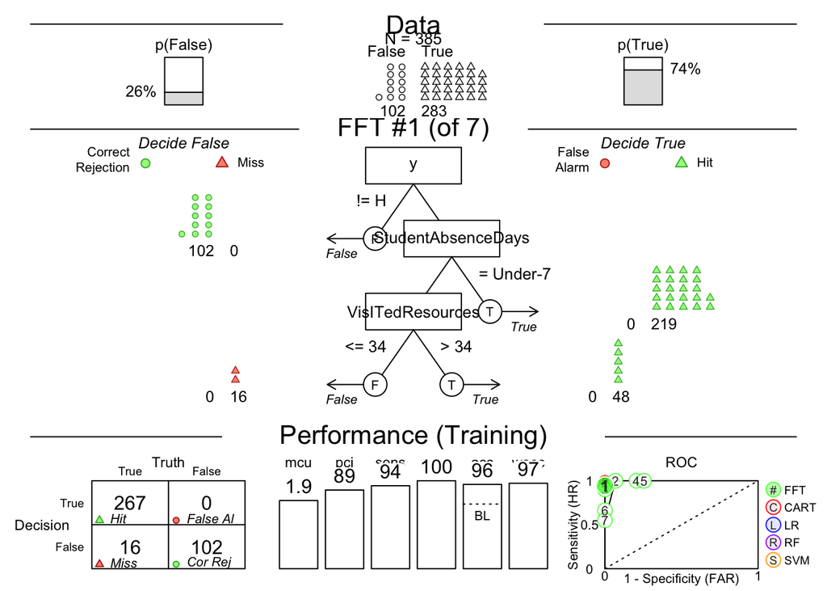

```r
fftree_model <- FFTrees(formula = ybin ~ .,
                     data = educ_train2)
plot(fftree_model)
```

- Упражнение 7.

Используйте быстрые и стройные деревья для набора данных `def_train`. Помните, что целевая переменная в нём закодирована как ‘Yes’ и ‘No’.

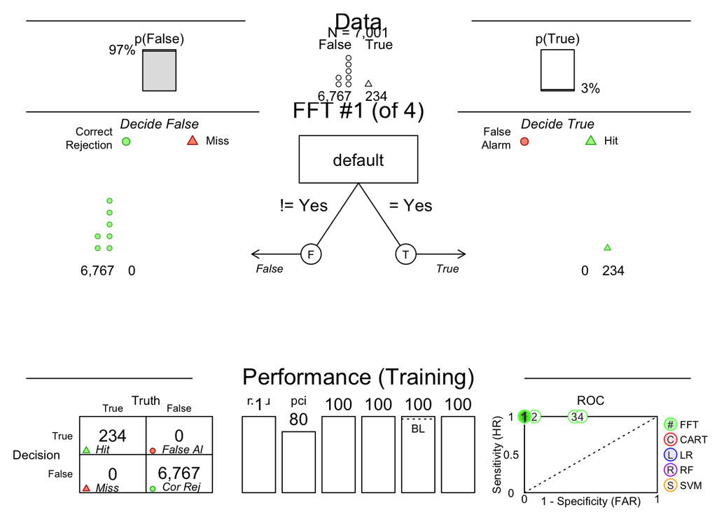

```r
def_train2 <- mutate(def_train, defaultbin = ifelse(default == 'Yes', 1, 0))

def_fftree <- FFTrees(formula = defaultbin ~ .,
                      data = def_train2)
plot(def_fftree)
```

# 3 Случайный лес

В алгоритме случайного леса мы

1. Выращиваем целый лес, скажем 500, деревьев.
2. Строим прогноз с помощью каждого дерева.
3. Агрегируем прогнозы деревьев. Можно в качестве итогового прогноза выбрать ту категорию, за которую проголосовало большинство деревьев. Можно оценить вероятности категорий, взяв процент деревьев, проголосовавших за ту или иную категорию.

Деревья оказываются не идеальными копиями друг друга по двум причинам:

1. Каждое дерево обучается на случайной выборке из исходной выборки. Обычно для каждого дерева берут подвыборку с повторениями из исходной выборки, так чтобы размер подвыборки равнялся размеру исходной выборки.
2. При каждом делении каждой ветки на две части происходит предварительный случайный отбор переменных. Скажем, из исходных 100 переменных, каждый раз случайно отбирается 10, а затем из этих 10 выбирается наилучшая, по которой ветвь и делится на две ветви.

У идеи есть куча вариантов исполнения, отличающихся деталями:

- критерием деления ветви на две;
- критерием остановки деления дерева;
- количеством предварительно отбираемых переменных перед каждым делением;
- количество деревьев;

Посмотрим на все вариации случайного леса, которые перебрал `ranger`.

```r
ranger_model <- train(y ~ ., data = educ_train,
                      method = 'ranger',
                      na.action = na.omit,
                      importance = 'impurity')
ranger_model
```

[output not shown]

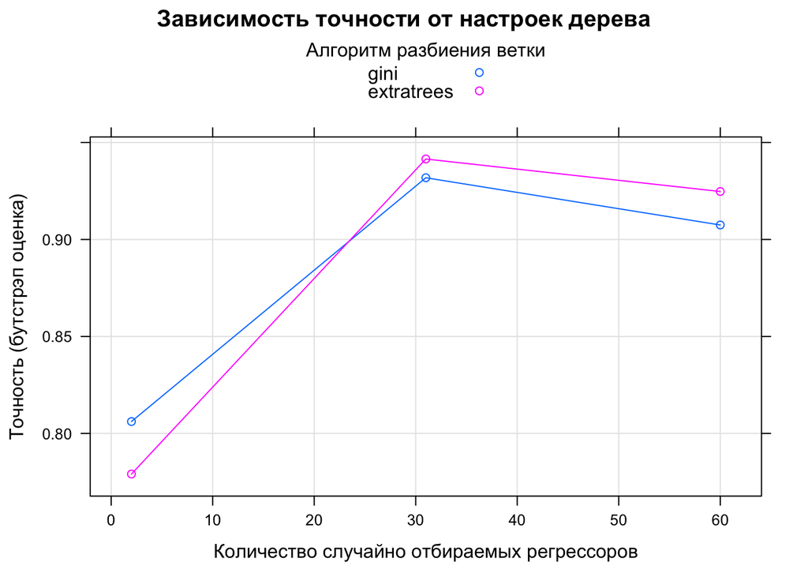

```r
plot(ranger_model,
  xlab = 'Количество случайно отбираемых регрессоров',
  ylab = 'Точность (бутстрэп оценка)',
  main = 'Зависимость точности от настроек дерева',
  auto.key = list(title = 'Алгоритм разбиения ветки', cex.title = 1))
```

Как мы поняли, что за название легенды отвечает аргумент `auto.key`?

1. Мы проверили класс созданного графика — `trellis`, значит, это `lattice`!
2. Потом загуглили ‘lattice change legend title’.
3. Нашли полезную [статью](https://magesblog.com/post/2012-12-04-changing-colours-and-legends-in-lattice/)
4. Профит!

И более подробно про наилучшую:

```r
ranger_model$finalModel
```

[output not shown]

- Упражнение 8.

Реализуйте случайный лес для данных про кредиты, выведите описание лучшей модели и постройте визуализацию.

```r
def_ranger <- train(default ~ ., data = def_train,
                    method = 'ranger',
                    importance = 'impurity')
def_ranger$finalModel
```

```
## Ranger result
##
## Call:
##  ranger::ranger(dependent.variable.name = ".outcome", data = x,      mtry = param$mtry, min.node.size = param$min.node.size, splitrule = as.character(param$splitrule),      write.forest = TRUE, probability = classProbs, ...)
##
## Type:                             Classification
## Number of trees:                  500
## Sample size:                      7001
## Number of independent variables:  3
## Mtry:                             2
## Target node size:                 1
## Variable importance mode:         impurity
## Splitrule:                        extratrees
## OOB prediction error:             3.04 %
```

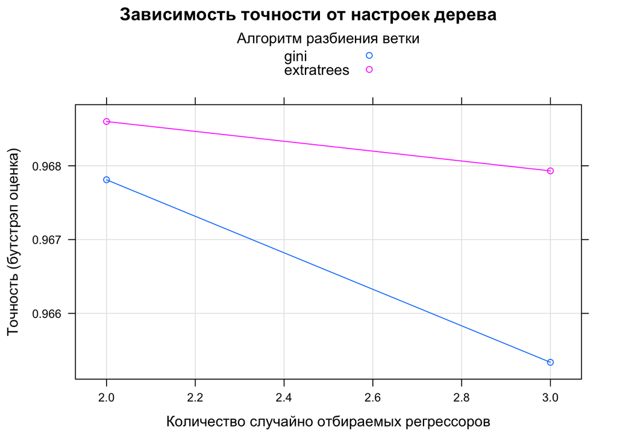

```r
plot(def_ranger,
xlab = 'Количество случайно отбираемых регрессоров',
ylab = 'Точность (бутстрэп оценка)',
main = 'Зависимость точности от настроек дерева',
auto.key = list(title = 'Алгоритм разбиения ветки', cex.title = 1))
```

Построить информативно на графике все сотни или тысячи деревьев невозможно.

Можно попытаться выделить важность переменных:

```r
ranger_import <- varImp(ranger_model)
ranger_import
```

```
## ranger variable importance
##
##   only 20 most important variables shown (out of 60)
##
##                              Overall
## StudentAbsenceDaysUnder-7    100.000
## VisITedResources              98.987
## AnnouncementsView             53.052
## ParentschoolSatisfactionGood  25.881
## raisedhands                   25.362
## Discussion                    16.172
## ParentAnsweringSurveyYes      11.608
## PlaceofBirthKuwaIT             7.550
## genderM                        5.557
## SectionIDB                     4.904
## GradeIDG-04                    4.726
## NationalITyJordan              4.646
## GradeIDG-07                    4.543
## PlaceofBirthJordan             4.412
## TopicEnglish                   4.398
## TopicMath                      4.258
## TopicIT                        3.462
## StageIDlowerlevel              3.385
## NationalITyKW                  3.243
## TopicScience                   2.898
```

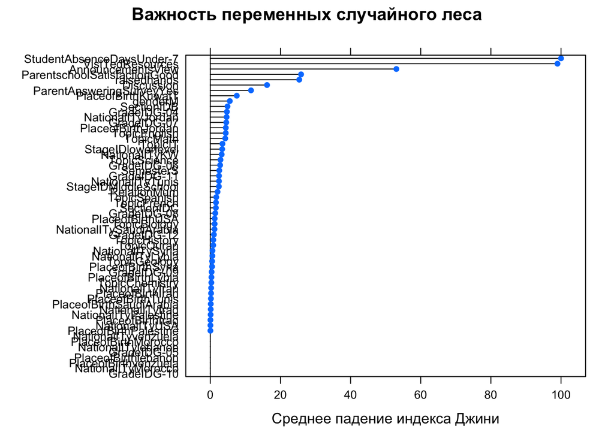

```r
plot(ranger_import,
    main = 'Важность переменных случайного леса',
    xlab = 'Среднее падение индекса Джини')
```

- Упражнение 9.

Выделите важность переменных в модели `def_ranger`.

```r
def_import <- varImp(def_ranger)
def_import
```

```
## ranger variable importance
##
##            Overall
## balance     100.00
## income       47.86
## studentYes    0.00
```

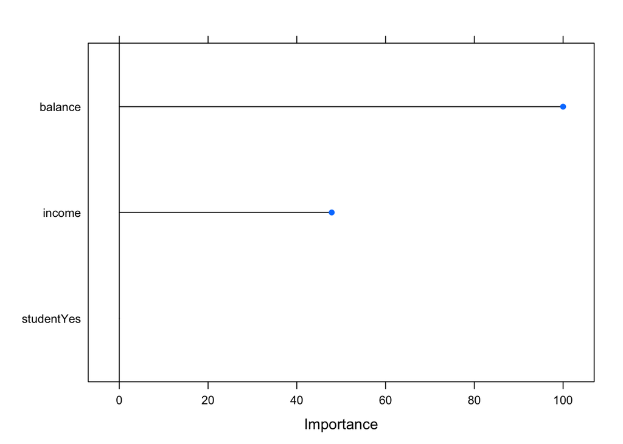

```r
plot(def_import)
```

И, конечно, построить прогнозы:

```r
educ_ranger <- mutate(educ_test,
  yhat = predict(ranger_model, educ_test, na.action = na.pass))
confusionMatrix(educ_ranger$yhat, educ_ranger$y)
```

```
## Confusion Matrix and Statistics
##
##           Reference
## Prediction  H  L
##          H 70  0
##          L  0 25
##
##                Accuracy : 1
##                  95% CI : (0.9619, 1)
##     No Information Rate : 0.7368
##     P-Value [Acc > NIR] : 2.515e-13
##
##                   Kappa : 1
##  Mcnemar's Test P-Value : NA
##
##             Sensitivity : 1.0000
##             Specificity : 1.0000
##          Pos Pred Value : 1.0000
##          Neg Pred Value : 1.0000
##              Prevalence : 0.7368
##          Detection Rate : 0.7368
##    Detection Prevalence : 0.7368
##       Balanced Accuracy : 1.0000
##
##        'Positive' Class : H
##
```

По умолчанию, пакет `caret` сам решает, сколько значений параметров перебирать и какие конкретно.

Список перебираемых параметров:

```r
modelLookup(model = 'ranger')
```

```
##    model     parameter                         label forReg forClass
## 1 ranger          mtry #Randomly Selected Predictors   TRUE     TRUE
## 2 ranger     splitrule                Splitting Rule   TRUE     TRUE
## 3 ranger min.node.size             Minimal Node Size   TRUE     TRUE
##   probModel
## 1      TRUE
## 2      TRUE
## 3      TRUE
```

Но мы можем заказать перебор любых.

Можно заказать количество перебираемых значений для каждого параметра:

```r
ranger_model <- train(y ~ ., data = educ_test,
                      method = "ranger",
                      na.action = na.omit,
                      importance = 'impurity',
                      tuneLength = 4)
```

Или явно значения

```r
grid <- expand.grid(mtry = c(5, 10), min.node.size = c(1, 5), splitrule = 'gini')

ranger_model <- train(y ~ ., data = educ_test,
            tuneGrid = grid, method = "ranger", na.action = na.omit)
ranger_model
```

```
## Random Forest
##
## 95 samples
## 16 predictors
##  2 classes: 'H', 'L'
##
## No pre-processing
## Resampling: Bootstrapped (25 reps)
## Summary of sample sizes: 95, 95, 95, 95, 95, 95, ...
## Resampling results across tuning parameters:
##
##   mtry  min.node.size  Accuracy   Kappa
##    5    1              0.9491514  0.8653158
##    5    5              0.9398125  0.8406229
##   10    1              0.9557921  0.8834987
##   10    5              0.9527873  0.8744610
##
## Tuning parameter 'splitrule' was held constant at a value of gini
## Accuracy was used to select the optimal model using the largest value.
## The final values used for the model were mtry = 10, splitrule = gini
##  and min.node.size = 1.
```

# 4 Кросс-валидация для k ближайших соседей

Метод классификации k-ближайших соседей реализует пословицу «Скажи мне, кто твой друг, и я скажу, кто ты». Мы прогнозируем класс нового наблюдения, как наиболее часто встречающийся класс у ближайших соседей данного наблюдения.

Реализуем метод k ближайших соседей для набора данных про студентов. Подбирать число соседей будем с помощью кросс-валидации. Для этого у объекта `trainControl` зададим опции `method = 'cv'` и `number = 5`. Первая отвечает за тип кросс-валидации, а вторая за колиество разбиений выборки. В настройках обучения `train` укажем метод `knn`, добавим параметры кросс-валидции из объекта `trxrl`, а также попросим центрировать и отмасштабировать данные.

```r
trctrl <- trainControl(method = 'cv', number = 5)

set.seed(777)
educ_knn_fit <- train(y ~., data = educ_train, method = 'knn',
                      trControl = trctrl,
                      preProcess = c('center', 'scale'))

educ_knn_fit
```

```
## k-Nearest Neighbors
##
## 385 samples
##  16 predictor
##   2 classes: 'H', 'L'
##
## Pre-processing: centered (60), scaled (60)
## Resampling: Cross-Validated (5 fold)
## Summary of sample sizes: 308, 308, 308, 309, 307
## Resampling results across tuning parameters:
##
##   k  Accuracy   Kappa
##   5  0.8285960  0.5182881
##   7  0.8129081  0.4794467
##   9  0.8259644  0.5090629
##
## Accuracy was used to select the optimal model using the largest value.
## The final value used for the model was k = 5.
```

Визуализируем долю правильных ответов в зависимости от числа соседей.

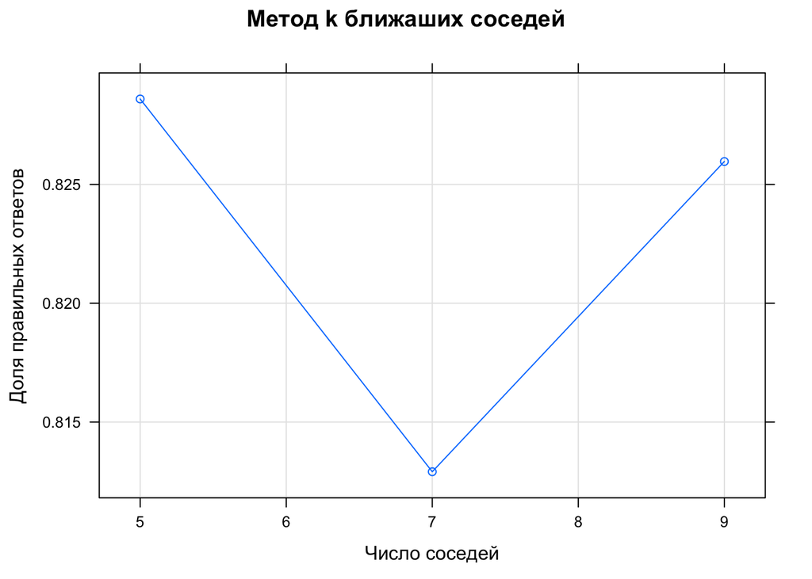

```r
plot(educ_knn_fit, xlab = 'Число соседей',
     ylab = 'Доля правильных ответов',
     main = 'Метод k ближаших соседей')
```

- Упражнение 10.

Реализуйте метод k ближайших соседей на данных о кредитах. Не забудьте центрировать и отмасштабировать их! Затем визуализрйуте полученный результат.

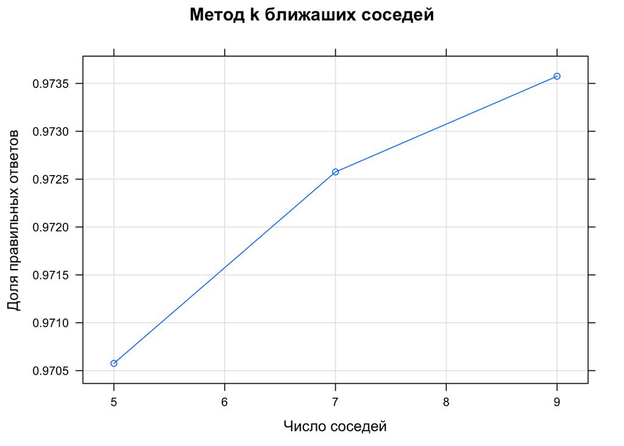

```r
def_knn_fit <- train(default ~ ., data = def_train, method = 'knn',
                     trControl = trctrl,
                     preProcess = c('center', 'scale'))

plot(def_knn_fit, xlab = 'Число соседей',
     ylab = 'Доля правильных ответов',
     main = 'Метод k ближаших соседей')
```

Теперь получим прогнозы для тестовой выборки и оценим их качество.

```r
educ_knn_predict <- predict(educ_knn_fit, newdata = educ_test)
confusionMatrix(educ_knn_predict, educ_test$y)
```

```
## Confusion Matrix and Statistics
##
##           Reference
## Prediction  H  L
##          H 65  7
##          L  5 18
##
##                Accuracy : 0.8737
##                  95% CI : (0.7897, 0.933)
##     No Information Rate : 0.7368
##     P-Value [Acc > NIR] : 0.0009533
##
##                   Kappa : 0.6657
##  Mcnemar's Test P-Value : 0.7728300
##
##             Sensitivity : 0.9286
##             Specificity : 0.7200
##          Pos Pred Value : 0.9028
##          Neg Pred Value : 0.7826
##              Prevalence : 0.7368
##          Detection Rate : 0.6842
##    Detection Prevalence : 0.7579
##       Balanced Accuracy : 0.8243
##
##        'Positive' Class : H
##
```

- Упражнение 11.

Постройте прогнозы метода k ближайших соседей для данных по кредитам и оцените их качество.

```r
def_knn_pred <- predict(def_knn_fit, newdata = def_test)
confusionMatrix(def_knn_pred, def_test$default)
```

```
## Confusion Matrix and Statistics
##
##           Reference
## Prediction   No  Yes
##        No  2879   64
##        Yes   21   35
##
##                Accuracy : 0.9717
##                  95% CI : (0.9651, 0.9773)
##     No Information Rate : 0.967
##     P-Value [Acc > NIR] : 0.08142
##
##                   Kappa : 0.4382
##  Mcnemar's Test P-Value : 5.225e-06
##
##             Sensitivity : 0.9928
##             Specificity : 0.3535
##          Pos Pred Value : 0.9783
##          Neg Pred Value : 0.6250
##              Prevalence : 0.9670
##          Detection Rate : 0.9600
##    Detection Prevalence : 0.9813
##       Balanced Accuracy : 0.6731
##
##        'Positive' Class : No
##
```